# Intro1 - Homework

Vishal Bakshi  
Tuesday, August 25, 2020

## Batch Size

I changed the batch size for one of the image classifiers we trained in intro notebook to this course, and noticed that the valid_loss value changed significantly.

I'll run the image classifier models to show you what I mean:

```python
from fastai.vision.all import *
path = untar_data(URLs.PETS)/'images'
def is_cat(x): return x[0].isupper()
log = {'pets': {
    2 : 0,
    4 : 0,
    8 : 0,
    16: 0
}, 'segmentation': {
    2 : 0,
    4 : 0,
    8 : 0,
    16: 0
}}

for i in range(4):
    batch_size = 2**(i+1)
    dls = ImageDataLoaders.from_name_func(
        path, get_image_files(path), bs=batch_size, valid_pct=0.2, seed=42,
        label_func=is_cat, item_tfms=Resize(224))
    learn = cnn_learner(dls, resnet34, metrics=error_rate)
    learn.fine_tune(1)
    log['pets'][batch_size] = learn.final_record[1]
```

| epoch | train_loss | valid_loss | error_rate | time |
| --- | --- | --- | --- | --- |
| 0 | 0.671831 | 0.144316 | 0.050744 | 01:51 |

| epoch | train_loss | valid_loss | error_rate | time |
| --- | --- | --- | --- | --- |
| 0 | 0.646514 | 0.352912 | 0.138024 | 02:21 |

| epoch | train_loss | valid_loss | error_rate | time |
| --- | --- | --- | --- | --- |
| 0 | 0.418658 | 0.077647 | 0.024357 | 01:00 |

| epoch | train_loss | valid_loss | error_rate | time |
| --- | --- | --- | --- | --- |
| 0 | 0.179817 | 0.050372 | 0.011502 | 01:13 |

| epoch | train_loss | valid_loss | error_rate | time |
| --- | --- | --- | --- | --- |
| 0 | 0.246792 | 0.049255 | 0.017591 | 00:32 |

| epoch | train_loss | valid_loss | error_rate | time |
| --- | --- | --- | --- | --- |
| 0 | 0.125174 | 0.023476 | 0.006089 | 00:43 |

| epoch | train_loss | valid_loss | error_rate | time |
| --- | --- | --- | --- | --- |
| 0 | 0.137739 | 0.052795 | 0.014208 | 00:24 |

| epoch | train_loss | valid_loss | error_rate | time |
| --- | --- | --- | --- | --- |
| 0 | 0.057923 | 0.013332 | 0.003383 | 00:33 |

```python
path = untar_data(URLs.CAMVID_TINY)

for i in range(4):
    batch_size = 2**(i+1)
    dls = SegmentationDataLoaders.from_label_func(
        path, bs=batch_size, fnames = get_image_files(path/"images"),
        label_func = lambda o: path/'labels'/f'{o.stem}_P{o.suffix}',
        codes = np.loadtxt(path/'codes.txt', dtype=str)
    )
    learn = unet_learner(dls, resnet34)
    learn.fine_tune(8)
    log['segmentation'][batch_size] = learn.final_record[1]
```

| epoch | train_loss | valid_loss | time |
| --- | --- | --- | --- |
| 0 | 1.753514 | 1.250025 | 00:04 |

| epoch | train_loss | valid_loss | time |
| --- | --- | --- | --- |
| 0 | 1.133678 | 1.048806 | 00:03 |
| 1 | 1.102538 | 1.008577 | 00:03 |
| 2 | 0.981480 | 0.827040 | 00:03 |
| 3 | 0.845606 | 0.736060 | 00:03 |
| 4 | 0.742655 | 0.778525 | 00:03 |
| 5 | 0.644585 | 0.667181 | 00:03 |
| 6 | 0.571420 | 0.669122 | 00:03 |
| 7 | 0.525055 | 0.656813 | 00:03 |

| epoch | train_loss | valid_loss | time |
| --- | --- | --- | --- |
| 0 | 2.513621 | 2.418835 | 00:03 |

| epoch | train_loss | valid_loss | time |
| --- | --- | --- | --- |
| 0 | 1.627781 | 1.192425 | 00:02 |
| 1 | 1.382911 | 1.021066 | 00:02 |
| 2 | 1.208196 | 0.872863 | 00:02 |
| 3 | 1.083026 | 0.861396 | 00:02 |
| 4 | 0.955392 | 0.667616 | 00:02 |
| 5 | 0.841550 | 0.637717 | 00:02 |
| 6 | 0.751018 | 0.609362 | 00:02 |
| 7 | 0.684736 | 0.602068 | 00:02 |

| epoch | train_loss | valid_loss | time |
| --- | --- | --- | --- |
| 0 | 2.916275 | 2.496579 | 00:03 |

| epoch | train_loss | valid_loss | time |
| --- | --- | --- | --- |
| 0 | 2.078728 | 1.570321 | 00:01 |
| 1 | 1.735551 | 1.315718 | 00:01 |
| 2 | 1.524138 | 1.064513 | 00:01 |
| 3 | 1.349213 | 0.929341 | 00:01 |
| 4 | 1.203711 | 0.811217 | 00:01 |
| 5 | 1.077349 | 0.751397 | 00:01 |
| 6 | 0.973786 | 0.733066 | 00:01 |
| 7 | 0.896015 | 0.722129 | 00:01 |

| epoch | train_loss | valid_loss | time |
| --- | --- | --- | --- |
| 0 | 3.222250 | 2.311272 | 00:02 |

| epoch | train_loss | valid_loss | time |
| --- | --- | --- | --- |
| 0 | 2.168895 | 1.820541 | 00:01 |
| 1 | 1.927316 | 1.797157 | 00:01 |
| 2 | 1.764727 | 1.526917 | 00:01 |
| 3 | 1.617956 | 1.200572 | 00:01 |
| 4 | 1.495027 | 1.048440 | 00:01 |
| 5 | 1.390191 | 0.985106 | 00:01 |
| 6 | 1.297539 | 0.928951 | 00:01 |
| 7 | 1.223987 | 0.911800 | 00:01 |

```python
temp_log = log.copy()
```

## Pets Image Classification Learner

For the pets dataset, the error rate decreases as batch size increases.

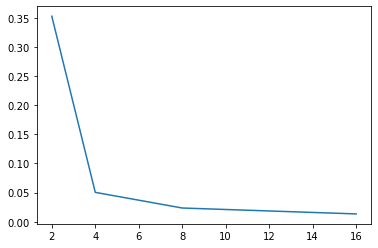

```python
plt.plot(log['pets'].keys(), log['pets'].values())
```

## Segmentation Learner

For the segmentation learner, the best performance was for a batch size of 4 images.

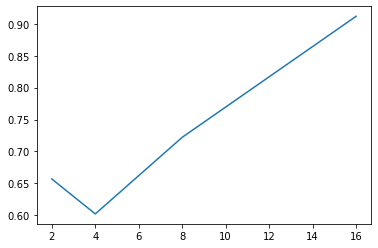

```python
plt.plot(log['segmentation'].keys(), log['segmentation'].values())
```

The next day, I came across [a very relevant fast.ai forum post](https://forums.fast.ai/t/simulating-smaller-batch-size-without-decreasing-speedup-from-having-larger-batch-size/68630/2) which spoke of various reasons that smaller batch sizes may result in a lower loss in the validation set which led me to find [this exchange on the same question](https://stats.stackexchange.com/questions/164876/tradeoff-batch-size-vs-number-of-iterations-to-train-a-neural-network) which referenced the following excerpt from a paper on this topic:

> *In this paper, we present ample numerical evidence that supports the view that large-batch methods tend to converge to sharp minimizers of the training and testing functions -- and that sharp minima lead to poorer generalization.*

From what I understood from [that paper](https://arxiv.org/abs/1609.04836) after a very quick skim was that larger batch sizes are sensitive to sharp minima and can't find their way out quick enough like smaller batches can. one result of this is that the model does not generalize well. a sharp minima means a very few number of x-values correspond to a y-value which is close to the minima. a smooth or flat minima means many x-values that correspond to a y-value which is close to the minima. as your model is tested with new data, there's a wider breadth of inputs that can lead to the ideal output. a model trained on sharp minima is picky. a model trained on smooth minima is less picky. the paper ended with a series of questions for next steps and my favorite one was:

> (e) is it possible,through algorithmic or regulatory means to steer LB methods away from sharp minimizers?

And I'll have to go and find what's already out there on this!

## Data Loaders and TensorImages

It turns out that `dls` is an iterable that holds two `DataLoader`s: one for the training set, and one for the validation set:

```python
dls[0] == dls.train
```

```
True
```

```python
dls[1] == dls.valid
```

```
True
```

Each `DataLoader` holds the batch size number of images (recall that the final learner was trained with a batch size of 16):

```
Clipping input data to the valid range for imshow with RGB data ([0..1] for floats or [0..255] for integers).
```

```
length of dataloader:  16
tensor: torch.Size([3, 96, 128])
tensor.permute(1,2,0): torch.Size([96, 128, 3])
```

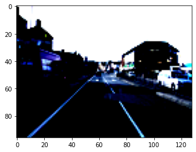

```python
i = 0
for dl in dls[0]:
    print('length of dataloader: ', len(dl[0]))
    img = dl[0][15]
    print('tensor:',img.size())
    print('tensor.permute(1,2,0):', img.cpu().permute(1,2,0).size())
    plt.imshow(img.cpu().permute(1,2,0))
    i += 1
    if i == 1: break
```

```
Clipping input data to the valid range for imshow with RGB data ([0..1] for floats or [0..255] for integers).
```

```
length of dataloader:  16
tensor: torch.Size([3, 96, 128])
tensor.permute(2,1,0): torch.Size([128, 96, 3])
```

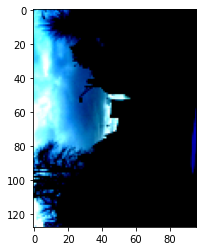

```python
i = 0
for dl in dls[0]:
    print('length of dataloader: ', len(dl[0]))
    img = dl[0][15]
    print('tensor:',img.size())
    print('tensor.permute(2,1,0):', img.cpu().permute(2,1,0).size())
    plt.imshow(img.cpu().permute(2,1,0))
    i += 1
    if i == 1: break
```

Lastly, the image looks burnt meaning it's likely that the image data is not normalized. Thanks to [ptrblck's consistently helpful replies in the pytorch forums](https://discuss.pytorch.org/t/typeerror-invalid-dimensions-for-image-data/35888/4) I was able to fix that:

```
length of dataloader:  16
tensor: torch.Size([3, 96, 128])
tensor.permute(1,2,0): torch.Size([96, 128, 3])
```

[figure not shown]

```python
i = 0
for dl in dls[0]:
    print('length of dataloader: ', len(dl[0]))
    img = dl[0][15]
    img -= img.min()
    img /= img.max()
    print('tensor:',img.size())
    print('tensor.permute(1,2,0):', img.cpu().permute(1,2,0).size())
    plt.imshow(img.cpu().permute(1,2,0))
    i += 1
    if i == 1: break
```